[*Home*](https://shivchitinous.github.io/optimal-forager/) | [*Binder*](https://mybinder.org/v2/gh/shivChitinous/optimal_forager/master) | [*Colab*](https://colab.research.google.com/github/shivChitinous/optimal_forager/blob/master/Optimal_Foraging_Theory.ipynb#scrollTo=mzQSlPyPiF76)

# Explicit Description of the Marginal Value Theorem

While the biological intuition for MVT is straightforward, an explicit numerical description might help the reader develop a better understanding of optimal foraging in patchy habitats.

## Further Reading

This is a toy model. Refer to Charnov's original study and [Parker and Stuart's superb analysis](https://www.jstor.org/stable/2460030) of it. Additionally, refer to the [reanalysis by Calgagno et al.](https://link.springer.com/article/10.1007/s00285-013-0734-y)

For a biological description, refer to [Begon, Townsend and Harper 4th Ed](https://www.wiley.com/en-us/Ecology%3A+From+Individuals+to+Ecosystems%2C+4th+Edition-p-9781405111171).

## Patch Function

Let's define the equation governing rate of resource consumption for a patch:

$$ \\ \dot I = r e^{-(t-T)/r} \ | \ t>T$$

$$ \\ \dot I = 0 \ | \ t<T$$

*Note:* Any function that decreases monotonically when *t>T* should do the job; except for a resource rich patch, $\ddot I$ should be lower than that for a resource poor patch

(for fun, try: $\dot I = r e^{-(t-T)}$)

$I$ is the **Net Resource Gain**

$r$ is **Resource Richness or Foraging Efficiency**

$T$ is **Traveling Time**

Play around with the parameters to see how $\dot I,\ I$ change as a function of time (*open with Binder or Google Colab*).

```python
#defining time limit
t_max = 10
#assigning parameters
r = 1 #resource richness
T = 3 #traveling time
```

```python
def f(r,T,t):
    I_dot = r*(np.exp(-(1/r)*(t-T))) #try r*(np.exp(-(t-T)))
    I_dot[t<=T] = 0
    return I_dot
```

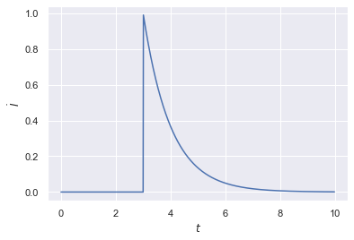

The rate of resource consumption decreases exponentially

```python
#numerically integrate I_dot to get a curve for cumulative resource consumed over time
def euler(dt, t_max, I_dot):
    I = np.zeros(np.size(t))
    I_p = 0
    for inst in np.arange(0,t_max,dt):
        dI = I_dot[t==inst]*dt
        I[t==inst] = I_p + dI
        I_p = I[t==inst]
    return I
```

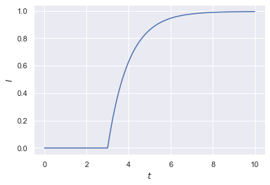

$I$ saturates as a function of $t$

```
optimal exit time =  4.76
```

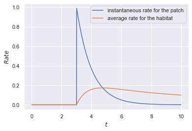

If the instantaneous rate of consumption falls below the **maximum** average rate for the habitat (made up of identical patches in this scenario), the organism should ideally abandon the patch and move on to a new one.

*How would you justify this?*

*Note:* Average rate is maximum when average rate and instantaneous rate intersect in the above graph. This is true when the habitat consists of only one type of patches.

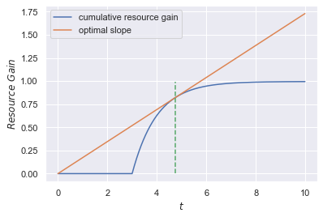

Note the tangential behaviour! (i.e the line passing through origin and through the point on the curve corresponding to the optimal exit time is tangential to the cumulative resource gain curve)

*Is it possible to prove this?*

## Comparing distinct habitats each with a single patch type

```python
#defining time limit
t_max = 10
#assigning paramaeters
r_a = 1
r_b = 1.5 #greater resource richness
T_a = 2
T_b = 2
```

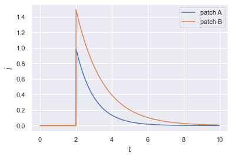

These are two different habitats, each having a single patch type

*How would one figure out which is resource poor and which is resource rich?*

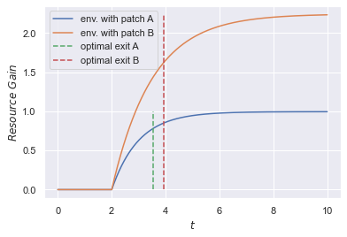

**Exit time is more for resource rich habitat!**

What happens for a habitat in which the resources are similar but traveling time is not? (change $T$ for the above habitats and verify for yourself)

What happens if parameter being considered is **Proportional Resource Gain** instead of **Cumulative Resource Gain**?

Let us normalise $I$ by $I_\text{max}$:

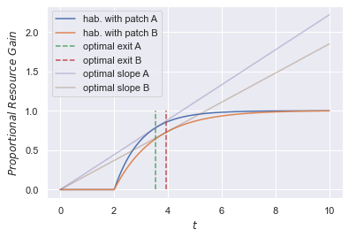

Note that even when we look at proportional resource gain, the line that passes through the origin and the *y* value at the optimal exit time is tangential to the proportional resource gain curve. *How would you go about proving this?*

## Single habitat with distinct patch types

In the previous case, we saw what the optimal exit time should be for an animal foraging in two distinct habitats, each with a single patch type. Now we will see what happens in the case of a single habitat with 2 distinct patch types.

In this habitat, the low resource patches and the high resource patches are equally abundant: Therefore, the average foraging rate for this habitat is going to be a mean of the average foraging rate for the two different patch types.

*Can you prove this?*

Here we consider the same parameters for patch A and patch B as in the case above:

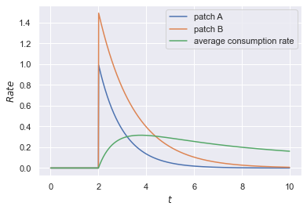

*Based on the above graph, when should the organism leave patch A and when should it leave patch B?*

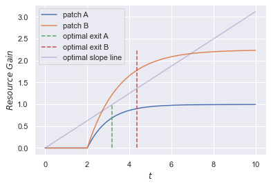

**Observe the tangential behaviour!** This is a result of the **Marginal Value Theorem**.

This can also be extended to the case where there are more than 2 patch types within a single habitat.

What happens when we look at **Proportional Resource Gain**? Do we still observe the tangential behaviour?

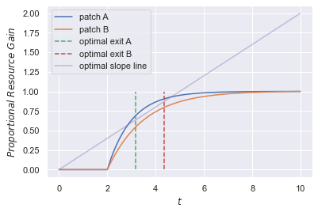

Nope. *Can you explain why?*